# An Introduction to the RecordTest Package

## Introduction

The **RecordTest** package (Inference Tools in Time Series Based on Record Statistics) contains functions to visualize the behaviour of the record occurrence, functions to calculate a wide variety of distribution-free tests for trend in location, variation and non-stationarity, for change-point detection, and tools to prepare a time series in order to study its records.

Install **RecordTest** using

```r
install.packages("RecordTest")
```

The **introductory theory** and **summary** for the package is at

```r
help("RecordTest-package")
```

Here, the main purpose of the package is developed as well as an outline of the functions available in the package.

**RecordTest** has several functions that attempt to test the classical record model which assumes randomness in its variables, that is, they are continuous independent and identically distributed, by means of hypothesis tests and graphical tools.

## Records in the 200-meter Olympic race

### Sports Data

To begin with, **RecordTest** has a dataset `Olympic_records_200m` containing the record times `time` and record values `value` of the Olympic 200-meter, from 1900 to 2020. In this case, only the lower records are available.

### Data preparation

The **RecordTest** functions need a complete series of observations to calculate its records. In order to apply these tools to the series of Olympic records, the function `series_record` is applied, which generates a series with the same records.

```r
library(RecordTest)
library(ggpubr) # To join plots
data(Olympic_records_200m, package = "RecordTest")

or200m <- series_record(L_lower = Olympic_records_200m$time,
                        R_lower = Olympic_records_200m$value,
                        Trows = 27)
```

### Some tests and graphical tools

As a preview, the Olympic records series is drawn highlighting its lower records.

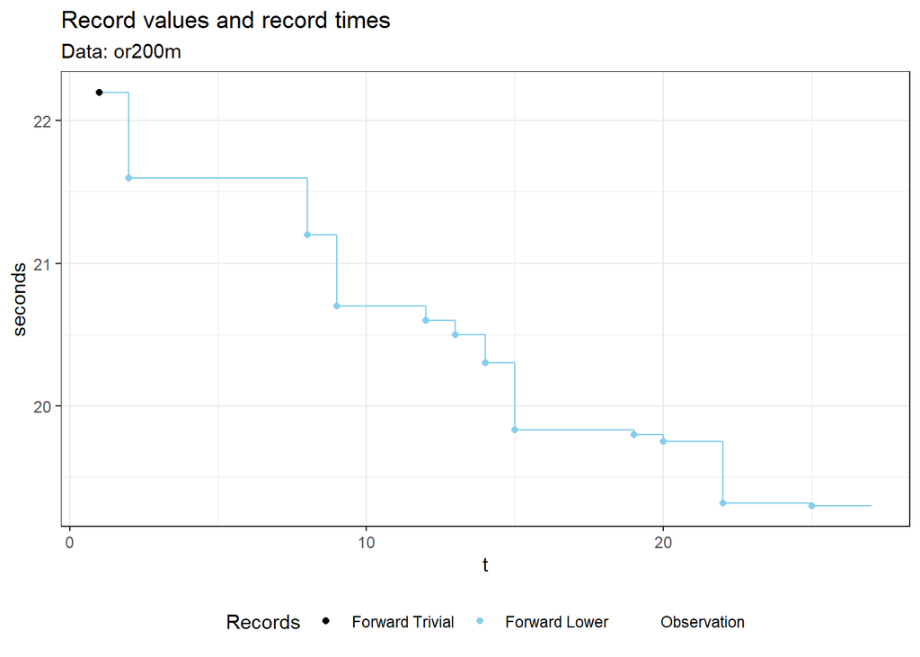

```r
records(or200m, type = "points", alpha = c(1,0,1,0)) + ggplot2::ylab("seconds")
```

The graph below shows the number of accumulated lower records together with its confidence intervals under the null hypothesis, from which we see that the observed sample departs significantly since time $t = 13$, corresponding to the 1960 Olympics.

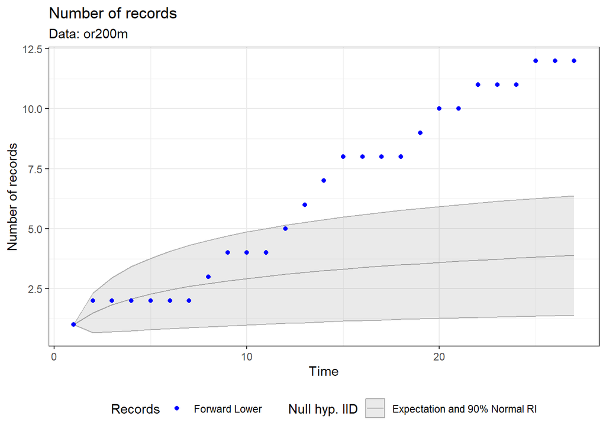

```r
N.plot(or200m, record = c(0,1,0,0))
```

Due to the sample size is not very large, an exact one-sided test can be implemented based on the Poisson binomial distribution. The result is highly significant. The number of observed records is 12 while the expected under the null hypothesis is close to 4.

```r
N.test(or200m, record = "lower", distribution = "poisson-binomial")
```

```
#>
#>  Test on the number of lower records
#>
#> data:  or200m
#> Poisson-binomial = 12, p-value = 1.5e-05
#> alternative hypothesis: true 'Poisson-binomial' is greater than 3.8915
```

## Records in temperatures and global warming

### Temperature Data

**RecordTest** has a benchmark temperature dataset `TX_Zaragoza` containing the time series `TX` of daily maximum temperature at Zaragoza (Spain), from 01/01/1951 to 31/12/2020 measured in tenths of a degree Celsius. In this case, the whole series is available.

### Data preparation

As a preview, the temperature series `TX_Zaragoza$TX` is drawn highlighting its upper and lower records.

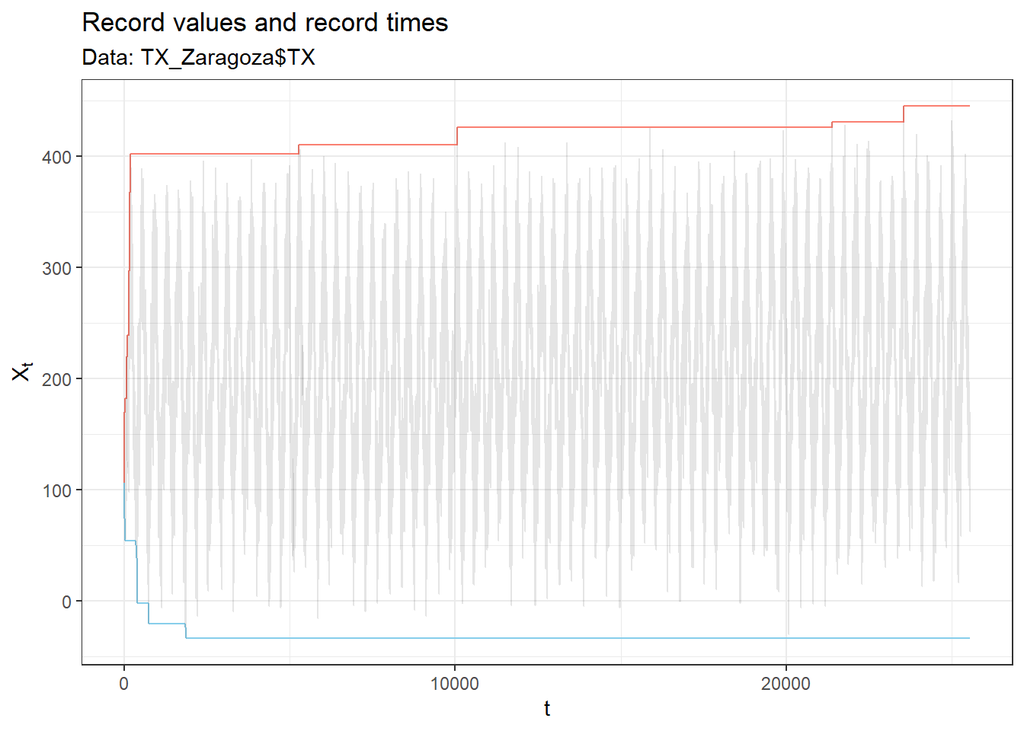

```r
data(TX_Zaragoza, package = "RecordTest")
records(TX_Zaragoza$TX, alpha = c(1, 1, 1, 0.1))
```

A large number of upper records are observed in the first observations and very few lower records. The initial behaviour in the records appear due to the seasonal increment of temperature between January and July, because this series has a strong seasonal component and serial correlation.

To take these characteristics into consideration, splitting the observed series into $M$ uncorrelated subseries is especially useful in the presence of serial correlation and seasonality. `series_split` splits `TX_Zaragoza$TX` into 365 subseries, each corresponding to each day of the year. `series_uncor` selects the larger number of columns or subseries that are not correlated with their adjacent columns.

```r
TxZ365 <- series_split(TX_Zaragoza$TX, Mcols = 365)
TxZ <- series_uncor(TxZ365)
dim(TxZ)
```

```
#> [1] 70 76
```

Since the observed series is measured and rounded to tenths of a degree Celsius, ties can occur, which may cause a lower number of records to be identified than actually occurred. In particular, we observe that around $4\%$ of the records are weak records.

```r
series_ties(TxZ365)
```

```
#> $number
#>              Total             Strong               Weak Expected under IID
#>               1969               1889                 80               1764
#>
#> $percentage
#> [1] 4.063
#>
#> $percentage.position
#>       1       2       3       4       5       6       7       8       9      10
#>  0.0000  2.4631  2.4590  0.0000  4.2105  6.4516  3.0769  1.6393  0.0000  3.4483
#>      11      12      13      14      15      16      17      18      19      20
#> 10.2564  3.7037  6.2500  2.4390 13.3333  0.0000  6.2500  9.0909 11.1111  0.0000
#>      21      22      23      24      25      26      27      28      29      30
#> 42.8571 22.2222  0.0000  0.0000  0.0000 16.6667  0.0000  5.5556 11.1111  8.3333
#>      31      32      33      34      35      36      37      38      39      40
#>  4.7619  7.1429 20.0000 18.1818 12.5000 14.2857  0.0000 10.0000  7.1429 10.5263
#>      41      42      43      44      45      46      47      48      49      50
#> 12.5000  6.2500  0.0000  8.3333  9.5238  0.0000  0.0000  0.0000  0.0000 25.0000
#>      51      52      53      54      55      56      57      58      59      60
#> 14.2857  0.0000  6.6667 16.6667  0.0000  0.0000  0.0000 20.0000  0.0000  0.0000
#>      61      62      63      64      65      66      67      68      69      70
#> 25.0000  3.8462  0.0000  5.5556  8.3333  0.0000  7.6923  0.0000  0.0000  0.0000
```

We could untie the possible records by adding a random value from a Uniform and independent distribution for each observation.

```r
set.seed(23)
TxZ <- series_untie(TxZ)
```

### Tests and graphics to detect trends

The following plot shows the upper and lower record times in the forward and backward series. Many more points are observed in the plots of the diagonal, giving evidence that there is a positive trend in the series.

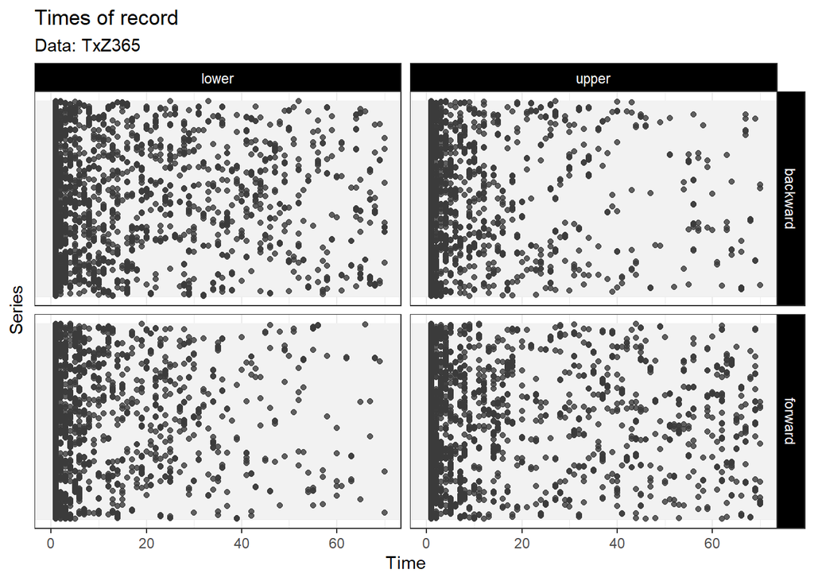

```r
L.plot(TxZ365)
```

The following plots show the mean number of (weighted) upper and lower records in the forward and backward series. Without weights the trend in the forward series is not significant, but backward it is highly significant. With weights, the trend in both directions is significant. This fact is produced because the evolution of temperature in Zaragoza is showing a faster increase since 1980.

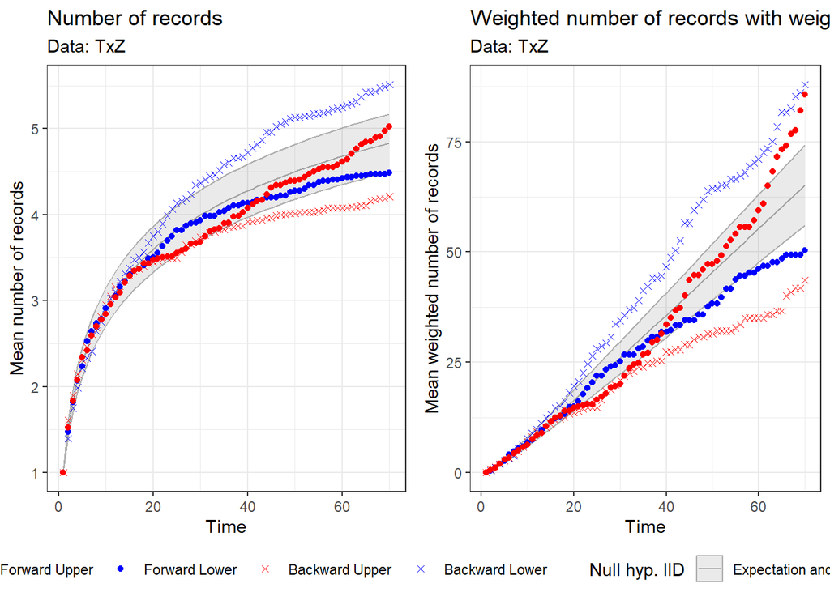

```r
ggpubr::ggarrange(N.plot(TxZ), N.plot(TxZ, weights = function(t) t-1),
        ncol = 2, nrow = 1, common.legend = TRUE, legend = "bottom")
```

A plot that gathers the information about the number of occurrences in the four types of record is obtained as follows.

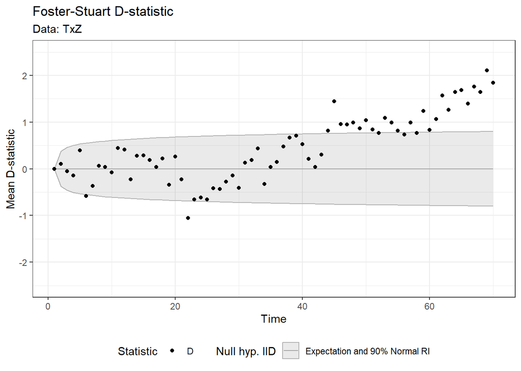

```r
foster.plot(TxZ) + ggplot2::ylim(-2.5, 2.5)
```

If we choose incremental weights $\omega_t = t-1$ to the records within the statistic, the trend becomes more significant earlier, then this graphical tool could be useful to identify the first time when non-stationary evidence appears. Several versions of plots of this style can be implemented (see `help(foster.plot)`).

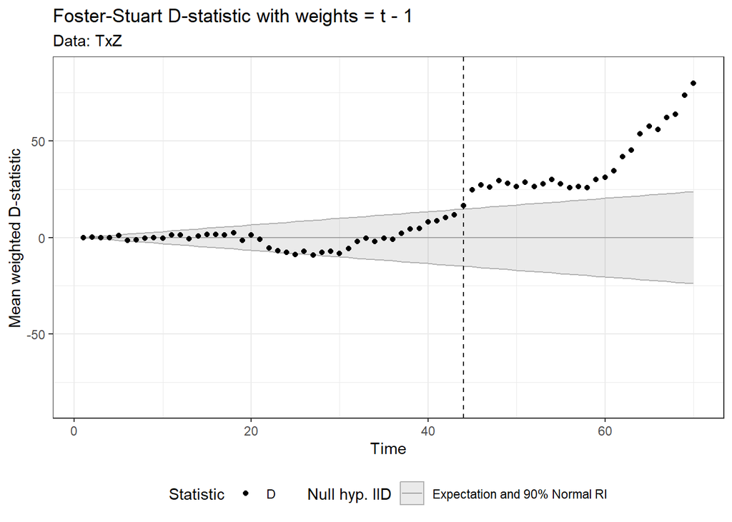

```r
foster.plot(TxZ, weights = function(t) t-1) +
  ggplot2::ylim(-85, 85) +
  ggplot2::geom_vline(xintercept = 44, linetype = "dashed")
```

We can apply the associated test to detect non-stationary behaviour in the records of the series. The result is highly significant.

```r
foster.test(TxZ, distribution = "normal", weights = function(t) t-1)
```

```
#>
#>  Foster-Stuart D-statistic test with weights = t - 1
#>
#> data:  TxZ
#> Z = 5.53, p-value = 1.6e-08
#> alternative hypothesis: true 'statistic' is greater than 0
#> sample estimates:
#> statistic         E       VAR
#>      6068         0   1203318
```

```r
foster.test(TxZ, distribution = "t", weights = function(t) t-1)
```

```
#>
#>  Foster-Stuart D-statistic test with weights = t - 1
#>
#> data:  TxZ
#> t = 5.4, df = 75, p-value = 3.7e-07
#> alternative hypothesis: true 't' is greater than 0
```

It is possible to use all the series if we compute the p-value with permutations, say 10,000:

```r
set.seed(23)
foster.test(TxZ365, distribution = "normal", weights = function(t) t-1,
  permutation.test = TRUE, B = 10000)
```

```
#>
#>  Foster-Stuart D-statistic test with weights = t - 1 with permuted
#>  p-value (based on 10000 permutations)
#>
#> data:  TxZ365
#> Z = 13.6, p-value <2e-16
#> alternative hypothesis: true 'statistic' is greater than 0
#> sample estimates:
#> statistic         E       VAR
#>     32801         0   5779093
```

Under the null hypothesis of randomness, the record probability meets $t p_t = 1$. An exploratory tool can be proposed where $E(t \hat p_t) = \alpha t + \beta$ and also a regression test for the hypothesis
$$H_0:\,\alpha=0,\,\beta=1 \qquad \text{and} \qquad
H_1:\,\alpha\neq0\,\text{or}\,\beta\neq1.$$
For Zaragoza data, plots related to this test detect a clear positive trend that is expressed with more upper records and less lower records in the forward series and the opposite in the backward series.

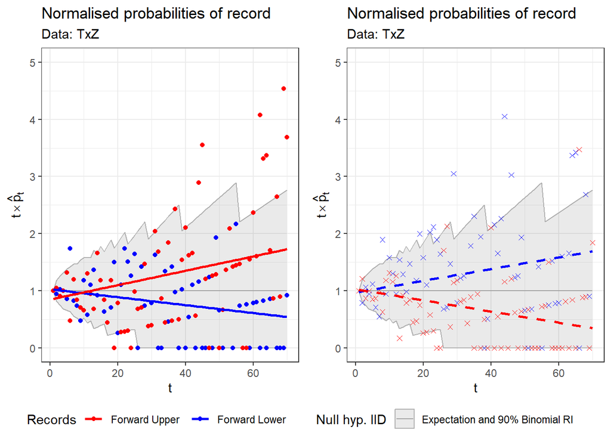

```r
ggpubr::ggarrange(
  p.plot(TxZ, record = c(1,1,0,0)) + ggplot2::ylim(0, 5),
  p.plot(TxZ, record = c(0,0,1,1)) + ggplot2::ylim(0, 5),
  ncol = 2, nrow = 1, common.legend = TRUE, legend = "bottom")
```

Those tests can be implemented as follows, where in addition the estimation of the parameters of the line is displayed.

```r
p.regression.test(TxZ, record = "upper")
```

```
#>
#>  Regression test on the upper records probabilities
#>
#> data:  TxZ
#> F = 5.37, df1 = 2, df2 = 67, p-value = 0.0069
#> alternative hypothesis: two-sided for record probabilities
#> null values:
#> (Intercept)           x
#>           1           0
#> sample estimates:
#> (Intercept)           x
#>    0.848373    0.012581
```

```r
p.regression.test(TxZ, record = "lower")
```

```
#>
#>  Regression test on the lower records probabilities
#>
#> data:  TxZ
#> F = 4.2, df1 = 2, df2 = 67, p-value = 0.019
#> alternative hypothesis: two-sided for record probabilities
#> null values:
#> (Intercept)           x
#>           1           0
#> sample estimates:
#> (Intercept)           x
#>   1.0283589  -0.0069164
```

```r
p.regression.test(series_rev(TxZ), record = "upper")
```

```
#>
#>  Regression test on the upper records probabilities
#>
#> data:  series_rev(TxZ)
#> F = 8.52, df1 = 2, df2 = 67, p-value = 0.00051
#> alternative hypothesis: two-sided for record probabilities
#> null values:
#> (Intercept)           x
#>           1           0
#> sample estimates:
#> (Intercept)           x
#>   1.0303789  -0.0097694
```

```r
p.regression.test(series_rev(TxZ), record = "lower")
```

```
#>
#>  Regression test on the lower records probabilities
#>
#> data:  series_rev(TxZ)
#> F = 5.33, df1 = 2, df2 = 67, p-value = 0.0071
#> alternative hypothesis: two-sided for record probabilities
#> null values:
#> (Intercept)           x
#>           1           0
#> sample estimates:
#> (Intercept)           x
#>    0.970841    0.010271
```

Other alternative based on a Monte Carlo approach is to join the information of all previous regression tests. Of the 1000 simulations considered under the null hypothesis, none has a statistic with a value greater than that of the observed series, making the test highly significant.

```r
set.seed(23)
global.test(TxZ, FUN = p.regression.test, B = 1000)
```

```
#>
#>  Test with global statistic for 'p.regression.test' with simulated
#>  p-value (based on 1000 replicates)
#>
#> data:  TxZ
#> Monte-Carlo = 23.4, p-value <2e-16
```

Other powerful tests for trend detection can be implemented as follows:

```r
brown.method(TxZ, weights = function(t) t-1)
```

```
#>
#>  Brown's method on the weighted number of records with weights = t - 1
#>
#> data:  TxZ
#> X-squared = 43, df = 4.76, c = 1.68, p-value = 2.8e-08
```

```r
N.test(TxZ, weights = function(t) t-1)
```

```
#>
#>  Test on the weighted number of upper records with weights = t - 1
#>
#> data:  TxZ
#> Z = 3.75, p-value = 8.7e-05
#> alternative hypothesis: true 'N' is greater than 4952.7
#> sample estimates:
#>        N        E      VAR
#>   6518.0   4952.7 173877.9
```

or

```r
set.seed(23)
p.chisq.test(TxZ, simulate.p.value = TRUE)
```

```
#>
#>  Chi-square test on the upper records probabilities with simulated
#>  p-value (based on 1000 replicates)
#>
#> data:  TxZ
#> X-squared = 129, df = 69, p-value <2e-16
```

```r
lr.test(TxZ, simulate.p.value = TRUE, B = 10000)
```

```
#>
#>  Likelihood-ratio test for upper record indicators with simulated
#>  p-value (based on 10000 replicates)
#>
#> data:  TxZ
#> LR = 2055, p-value = 0.028
#> alternative hypothesis: two.sided with different probabilities
```

```r
score.test(TxZ)
```

```
#>
#>  Score test for upper record indicators with simulated p-value (based on
#>  1000 replicates)
#>
#> data:  TxZ
#> LM = 6809, p-value <2e-16
#> alternative hypothesis: two.sided with different probabilities
```

Other plots:

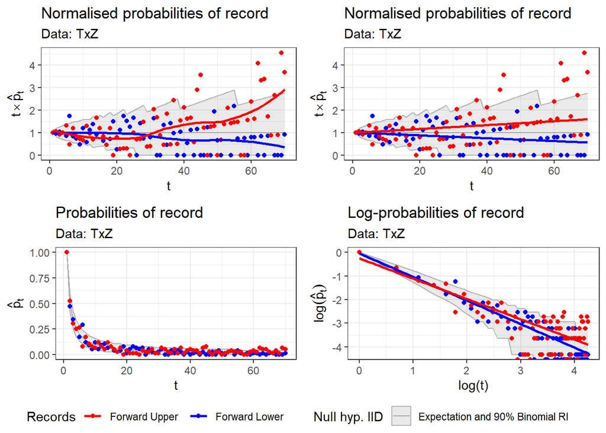

```r
ggpubr::ggarrange(
  p.plot(TxZ, plot = 1, record = c(1,1,0,0),
         smooth.method = stats::loess, span = 0.25),
  p.plot(TxZ, plot = 1, record = c(1,1,0,0),
         smooth.formula = y ~ I(x-1) - 1 + offset(rep(1, length(x)))),
  p.plot(TxZ, plot = 2, record = c(1,1,0,0)),
  p.plot(TxZ, plot = 3, record = c(1,1,0,0)),
  ncol = 2, nrow = 2, common.legend = TRUE, legend = "bottom")
```

### Tests to detect change-points

Signs of climate change have not been present since the beginning of the series. We can implement a test to detect change-points in the series on a daily scale as follows.

```r
change.point(ZaragozaSeries)
```

```
#>
#>  Records test for single changepoint detection
#>
#> data:  ZaragozaSeries
#> Kolmogorov = 2.08, p-value = 0.00035
#> alternative hypothesis: two.sided
#> sample estimates:
#> probable changepoint time
#>                        36
```

```r
change.point(ZaragozaSeries, weights = function(t) sqrt(t),
  record = "d", simulate.p.value = TRUE, B = 10000)
```

```
#>
#>  Records test for single changepoint detection with weights = sqrt(t)
#>  with simulated p-value (based on 10000 replicates)
#>
#> data:  ZaragozaSeries
#> Kolmogorov = 2.35, p-value = 1e-04
#> alternative hypothesis: two.sided
#> sample estimates:
#> probable changepoint time
#>                        36
```

The change-point is found at time 36 (1986). We can see analogous results for the annual mean temperature series, a change-point is significantly detected with time estimate 38 (1988).

```r
test.result <- change.point(rowMeans(TxZ365, na.rm = TRUE))
test.result
```

```
#>
#>  Records test for single changepoint detection
#>
#> data:  rowMeans(TxZ365, na.rm = TRUE)
#> Kolmogorov = 3.74, p-value = 1.4e-12
#> alternative hypothesis: two.sided
#> sample estimates:
#> probable changepoint time
#>                        38
```

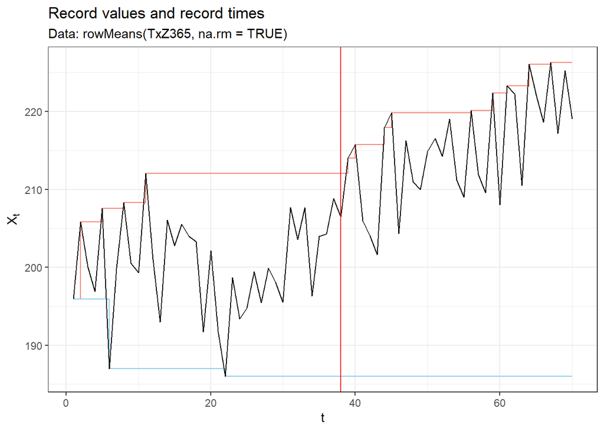

```r
records(rowMeans(TxZ365, na.rm = TRUE)) +
  ggplot2::geom_vline(xintercept = test.result$estimate, colour = "red")
```

There are still more tools! Try them yourself.